# Lecture 10 - Machine Learning

## 監督式學習

### Logistic regression (Lec. 7)

### 最近鄰居法K Nearest Neighbor (KNN)

最簡單和基本的分類法之一，可處理多元分類問題的演算法。當資料筆數很少或是很難獲得正確或是可靠的母體參數時，KNN是分類的最佳選擇之一。

先將訓練資料的每個變數定義成向量特徵空間，每筆資料在特徵空間中會有其對應的位置，如果當新的資料加入時，看它周圍的資料屬於哪一類別的最多，就將它判定為此類別。以距離作為未知類別的資料點分類依據，例如用 Euclidian distance measure 去看預測的與周圍k個資料的距離，但必須要將類別變數轉換為 dummy variables，需將所有的數值型變數標準化，避免因為單位不同，在距離的計算上失真。

$P(Y=j|X=x)=\frac{1}{k}\sum I(y_i=j)$

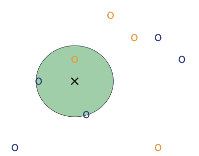

```
library(class)
knn(train$x, test$x, cl=traind$y, k)
#怎麼選擇適合的 k，通常 k 的上限為訓練樣本數的 20%。
```

### 決策樹Decision Tree

用樹狀圖或是決策模型把所有可能的結果都寫出來，並在其中加入機率、成本和效用。通常用在研究分析、決策分析，用來找出最可能達到目標的策略，用來描述條件機率的方法之一，不同的事件做出不同的決定，就會產生不同的結果，就好像樹的枝葉，每個節點都有機率性質在內，並包含時間先後概念。

決策樹的種類主要分成三種，若分類變數為類別型，則它是一般的分類樹，若是連續型變數則屬於迴歸樹，另外還有一種稱為 CART (Classification And Regression Trees)的決策樹類型，它是結合了上述兩種概念的決策樹，以反覆運算的方式，由根部開始反覆建立二元分支樹，直到樹節點中的同質性達到某個標準，或觸發反覆運算終止條件為止，且不限制變數的類型；由於分析上有較大的彈性，因此成為最受歡迎的決策樹分析方法之一。

優點：

- 可以同時處理連續型與類別型變數。
- 不需要進行太多的資料預處理。（例如不用作改成dummy variable）

缺點：

- 對於order資料，決策樹需要做很多預先處理的工作，且當要分析的類別太多時，錯誤率可能會明顯升高。

看區分的結果好壞：

- Gini index: 判斷結果是否區分清楚
- cross-entropy: 以資訊的複雜度探討新的變數是否能降低整體複雜度

（也就是下降多少不確定性，增加多少有用資訊）

```
library(rpart)
tree <- rpart(Ｙ ~. ,data=traind) # 樹模型
```

### 隨機森林Random Forests

An ensemble learning method for classification, regression and other tasks. 利用隨機(重新抽樣)的方法種植出許多決策樹，隨機森林將多棵決策樹合成一個森林，此森林輸出的類別是由個別樹輸出的類別的眾數而定。

隨機森林演算法會對資料從列方向（觀測值方向）與欄方向（變數方向）進行 Bootstrap sampling，得到不同的訓練資料，然後根據這些訓練資料得到一系列的決策樹分類器，以多數決方式決定預測結果。

優點：

- 訓練可以並行化，對於大規模樣本的訓練具有速度的優勢。
- 由於進行隨機選擇決策樹劃分特徵列表，這樣在樣本維度比較高的時候，仍然具有比較高的訓練性能。
- 可以給出各個特徵值的重要性列表。
- 由於存在隨機抽樣，訓練出來的模型MSE小，預測能力強。
- 簡單。對於部分特徵的丟失不敏感。
- 不用對它進行交叉驗證或者用一個獨立的測試集來獲得誤差的一個無偏估計。可直接依據計算袋外錯誤率oob error（out-of-bag error。

缺點：

- 噪音過大的特徵上，容易過度配適。
- 取值比較多的變數來分會對RF的決策產生更大的影響，從而影響模型的效果。

Note: 隨機森林跟以決策樹為基本分類器構成的 Bagging 有什麼不同？最大的差異應該就是隨機的部分，以決策樹為基本分類器構成的 Bagging 的 Boostrap sampling 只有應用在列方向（觀測值方向）；隨機森林的 bootstrap sampling 則是同時應用在列方向（觀測值方向）與欄方向（變數方向）。

```
library(randomForest)

randomForest(Species ~ ., data = traind, importane = T, ntree=100) # ntree表示森林中的樹木數量、importance計算每個模型中各屬性之重要值、norm.votes將最終投票結果轉為分數。OOB out-of-bag 為袋外錯誤率<每次抽樣中的袋外資料>

importance(model,type=1) # X對Y的重要性
```

http://www.blopig.com/blog/2017/04/a-very-basic-introduction-to-random-forests-using-r/

#### Bagging

Bagging 是 Bootstrap Aggregating 的簡稱。Bootstrap sampling 得到不同的訓練集，然後根據這些訓練集得到一系列的基本分類器，合併結果後以多數決的方式決定預測結果。Bagging的優點在於原始訓練樣本中有噪聲資料(不好的資料)，透過Bagging抽樣就有機會不讓有噪聲資料被訓練到，所以可以降低模型的不穩定性。

Bagging leads to improvements for unstable procedures: artificial neural networks, classification and regression trees, and subset selection in linear regression.

```
library(ipred)
bagging(model)
```

The out-of-bag estimate uses the observations which are left out in a bootstrap sample to estimate the misclassification error at almost no additional computational costs.

#### Boosting

Boosting works in a similar way as bagging, except that the trees are grown sequentially: each tree is grown using information from previously grown trees. Boosting does not involve bootstrap sampling; instead each tree is fit on a modified version of the original data set.

針對在前一個基本分類器中被分類錯誤的觀測值提高抽樣權重，使得該觀測值在下一個基本分類器形成時有更高機率被選入，藉此提高被正確分類的機率。由於Boosting針對分類錯誤的資料，因此Boosting對訓練資料的噪聲非常敏感，如噪聲資料很多，那後面分類器都會集中在進行噪聲資料上分類，影響最終的分類性能。

```
library(adabag)
boosting(model)
```

### Extreme Gradient Boosting - XGBoost

- 基於決策樹提升(Tree Boosting)的工具
- 使用level（depth）-wise tree生長策略
- 在訓練之前，預先對變數進行了排序，以確定最佳分割點，並重複使用這個排序，減少計算量。在進行節點的分裂時，需要計算每個特徵的增益，最終選增益最大的那個特徵去做分裂

```
install.packages("xgboost")
library(xgboost)
xgboost()
predict(model, test$y)
xgb.importance(model)
```

https://xgboost.readthedocs.io/en/stable/R-package/xgboostPresentation.html

### Light Gradient Boosted Machine - LightGBM

- 基於決策樹提升(Tree Boosting)的工具
- 相對 XGBoost 來說它具有訓練速度快、記憶體佔用低的特點
- 使用 leaf-wise tree 演算法，因此在迭代過程中能更快地收斂。但是 leaf-wise tree 方法可能生長出比較深的決策樹，較容易過擬合
- 是帶有深度限制的按葉子生長的策略，使用了leaf-wise策略，每次從當前所有葉子中，找到分裂增益最大的一個葉子，然後進行分裂，不斷的進行循環下去

```
library(lightgbm)
lgb.train()
lgb.importance(model, percentage = TRUE)
```

https://www.kaggle.com/code/andrewmvd/lightgbm-in-r

### 支持向量機Support Vector Machine (SVM)

支持向量機則是一種利用最適化（Optimization）概念在模型的精確度以及推廣能力（Generalization ability）中取得一個最佳平衡點的演算法，她在面對小樣本，非線性與多維度的資料中廣受歡迎。

找出一個適當的超平面並將資料分成兩類，運用核技巧應用於最大間隔超平面來建立非線性分類器的方法。

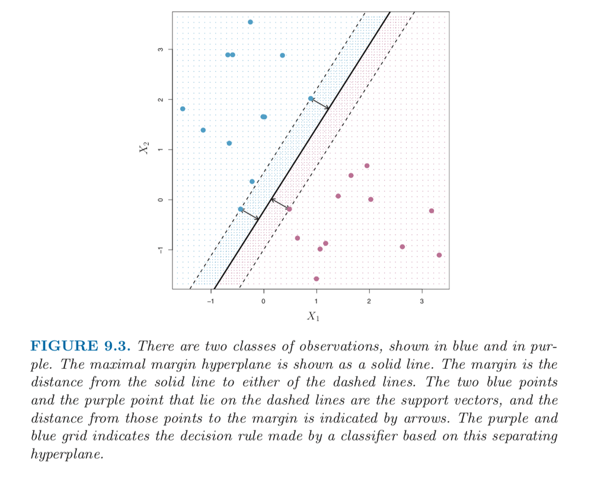

It separate different classes by a hyper plane which maximize the margin around the separating hyperplane. Let $X$ be a set of n points $x_i \in R^d$. Each $x_i$ has a label $y_i$. The hyperplane to separate the data is $f(x)=(\sum_{i}y_i\alpha_ik(x_i,x_j)) + b$, $b$ is the offset of the decision boundary from origin. It also works in non-linear decision boundary by using Kernel. The Kernel function can transform the nonlinear separable data into a higher dimensional space to do the linear separation. Commonly used Kernel functions ($k(x_i,x_j)$) between $x_i$ and $x_j$ in SVM are:

- linear: $x_i'x_j$
- polynomial kernel: $(\gamma x_i'x_j + coef)^d$, where d is the degree of the polynomial
- gaussian radial basis function(RBF): $exp(-\gamma \|x_i-x_j\|^2), \gamma \geq 0$
- sigmoid kernel: $tanh(\gamma x_i'x_j + coef)$

Parameters:

- Cost function錯了就懲罰。large C will cause low bias high variance. Use CV to find the best C.
- RBF: cost and gamma. Gamma 太小，模型就受到太多限制，無法抓出複雜的資料結構 `cost=10^(-1:2), gamma=c(.5, 1, 2)`

```
library(e1071)
svm(model, data)
tune(svm, model,data=traind,
                 kernel="radial", ranges=list(cost=10^(-1:2), gamma=c(.5,1,2)))
```

https://rpubs.com/skydome20/R-Note14-SVM-SVR

#### Example - 鳶尾花卉

library(datasets), data(iris), 四個解釋變數分別是花萼 長度、花萼寬度、花瓣長度和花瓣寬度。共分成三個品種，分別是山鳶尾、變色鳶尾和維吉尼亞鳶尾

#### Exercise - library(AER)，內建的1,319筆資料的CreditCard資料集

Try to use all the models we learned today to predict your test data.